# Visualizing your data with `ggplot`

Let’s add a palette we dig to our plot:

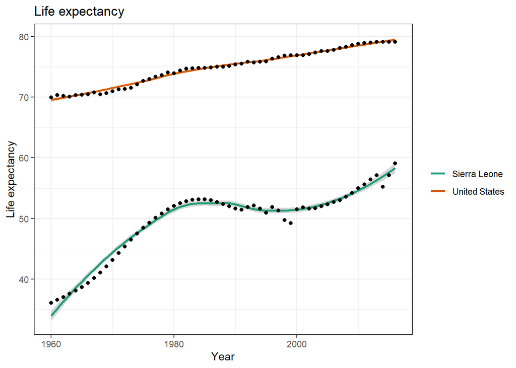

```r
p +
  scale_color_brewer(palette = "Dark2")
```

```r
library(wesanderson)
names(wes_palettes)
```

```
##  [1] "BottleRocket1"  "BottleRocket2"  "Rushmore1"      "Rushmore"
##  [5] "Royal1"         "Royal2"         "Zissou1"        "Darjeeling1"
##  [9] "Darjeeling2"    "Chevalier1"     "FantasticFox1"  "Moonrise1"
## [13] "Moonrise2"      "Moonrise3"      "Cavalcanti1"    "GrandBudapest1"
## [17] "GrandBudapest2" "IsleofDogs1"    "IsleofDogs2"
```

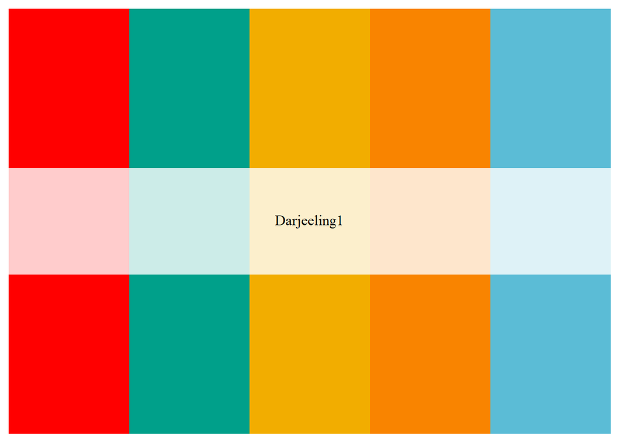

```r
wes_palette("Darjeeling1")
```

If you’re a bit more boring and really want a gray-scale plot, that’s easy too:

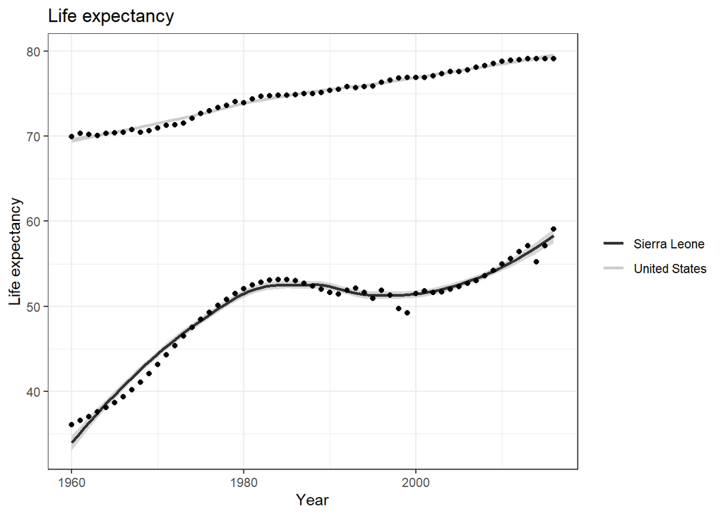

```r
p +
  scale_color_grey()
```

## Colorblind-friendly palettes

In recent years, there has been growing awareness about using palettes that are both color blind friendly and that transfer well to gray-scale (i.e. when converted to black and white).

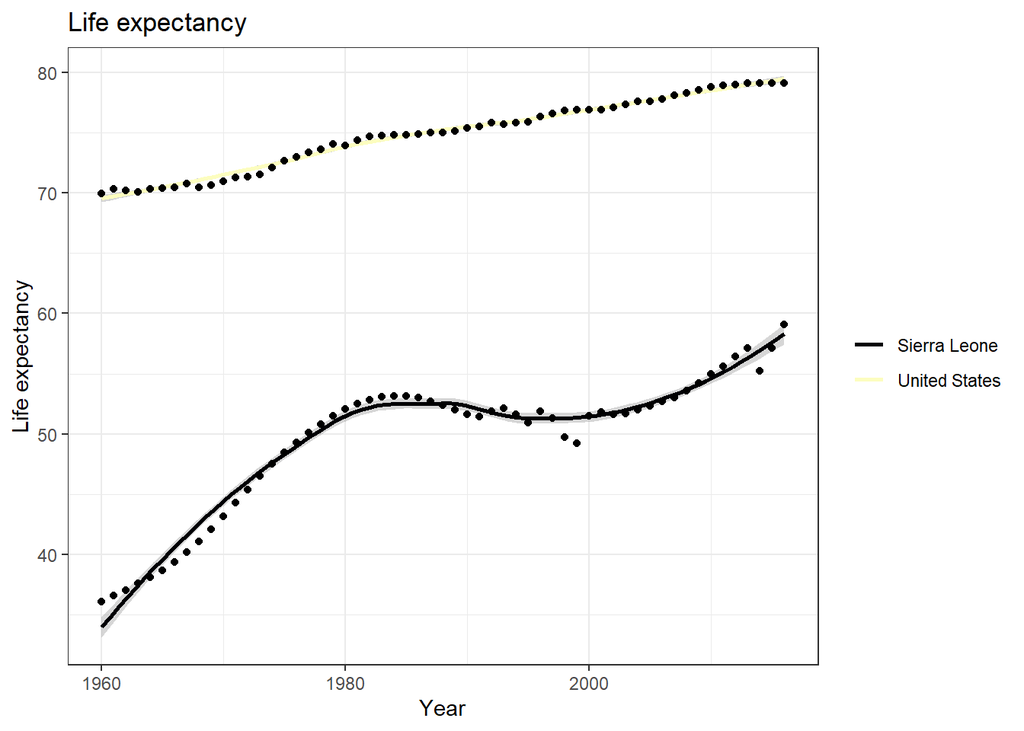

```r
library(viridis)
p +
  scale_color_viridis(discrete=T, option="magma")
```

Color options include `magma`, `plasma`, `viridis`, `inferno`, and `cividis`.

The `dichromat` package also contains color schemes suitable to folks who are color blind:

```r
library(dichromat)
names(dichromat::colorschemes)
```

```
##  [1] "BrowntoBlue.10"         "BrowntoBlue.12"         "BluetoDarkOrange.12"
##  [4] "BluetoDarkOrange.18"    "DarkRedtoBlue.12"       "DarkRedtoBlue.18"
##  [7] "BluetoGreen.14"         "BluetoGray.8"           "BluetoOrangeRed.14"
## [10] "BluetoOrange.10"        "BluetoOrange.12"        "BluetoOrange.8"
## [13] "LightBluetoDarkBlue.10" "LightBluetoDarkBlue.7"  "Categorical.12"
## [16] "GreentoMagenta.16"      "SteppedSequential.5"
```

I’ve found this [color-blindness simulator](https://www.color-blindness.com/coblis-color-blindness-simulator/) helpful when thinking about palette choices.

## Our final plot

Let’s wrap this all up in one lovely plot that includes some additional countries:

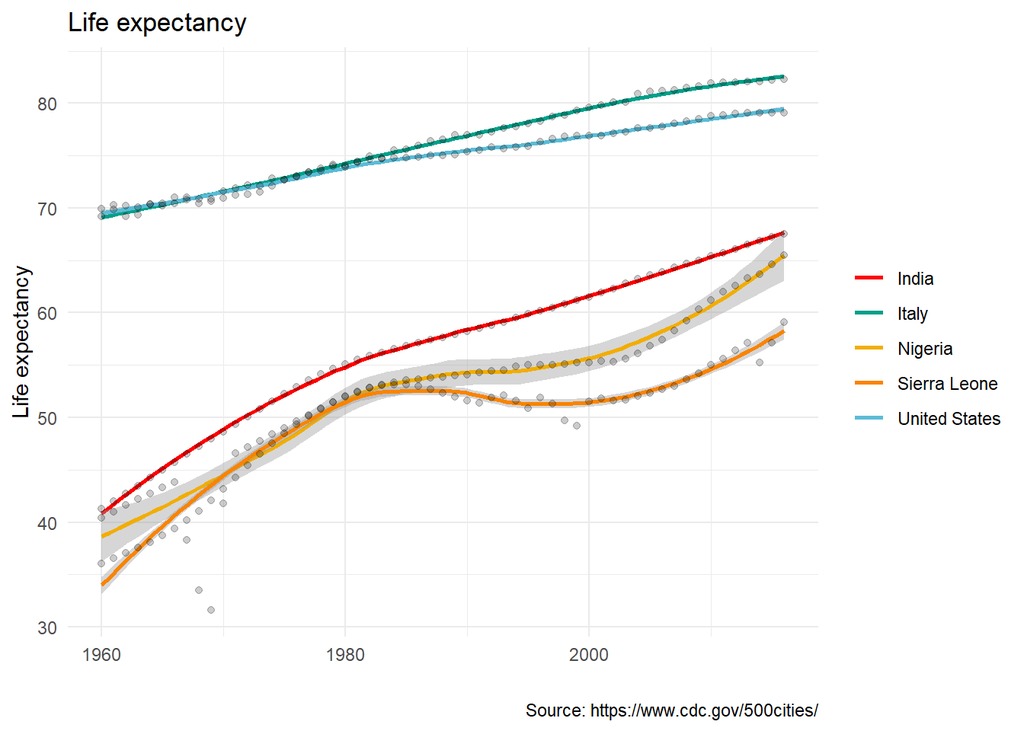

```r
gapminder %>%
  filter(country %in% c("Sierra Leone", "United States", "Italy", "Nigeria", "India")) %>%
  ggplot() +
  geom_smooth(mapping = aes(x = year, y = life_expectancy, color = country)) +
  geom_point(mapping = aes(x = year, y = life_expectancy), alpha = 0.2) + # alpha makes points transparent
  labs(x = "",
       y = "Life expectancy",
       title = "Life expectancy",
       caption = "Source: https://www.cdc.gov/500cities/") +
  theme_minimal() +
  theme(legend.title = element_blank()) +
  guides(color=guide_legend(override.aes=list(fill=NA))) +
  scale_color_manual(values = wes_palette(n=5, name="Darjeeling1"))
```